# Statistical Analysis Report

Xinyi Xie B00812989 Yixuan Wang B00815205 Yingwei Guo B00736113 Wenhui Wang B00843110

12/11/2020

## 1.Abstract

To better understanding the association between physical activity and obesity, the data was collected among the 55 states and districts in the US from the year of 2011 to the year of 2016. Here we only focused on the year of 2014 since it has the largest observations. And we focused question Q036, Q037 and Q047 to find out the association between physical activity and obesity.

## 2.Introduction

Data was collected based on behaviroal risk factor (physical activity and obesity) among the 55 states and districts in the US from 2011 to 2016. Questsions were asked among the 55 districts as follows:

- Q036:Percent of adults aged 18 years and older who have obesity;
- Q037:Percent of adults aged 18 years and older who have an overweight classification;
- Q018:Percent of adults who report consuming fruit less than one time daily;
- Q019:Percent of adults who report consuming vegetables less than one time daily;
- Q046:Percent of adults who engage in muscle-strengthening activities on 2 or more days a week;
- Q043:Percent of adults who achieve at least 150 minutes a week of moderate-intensity aerobic physical activity or 75 minutes a week of vigorous-intensity aerobic activity (or an equivalent combination);
- Q044:Percent of adults who achieve at least 150 minutes a week of moderate-intensity aerobic physical activity or 75 minutes a week of vigorous-intensity aerobic physical activity and engage in muscle-strengthening activities on 2 or more days a week;
- Q045:Percent of adults who achieve at least 300 minutes a week of moderate-intensity aerobic physical activity or 150 minutes a week of vigorous-intensity aerobic activity (or an equivalent combination);
- Q047:Percent of adults who engage in no leisure-time physical activity.

For each question, the proportion and corresponding confidence limit were provided. Additionally, sample size, age, education background, gender, income and race were also given.

## 3.Data Description

Introduce new data point:

Since our data is grouped according to different issues, we cannot add or reduce data to a single group. If new data is added to each group, it will require a lot of investigation and is difficult to achieve. Therefore, the data we add to the code will not have a big impact on future analysis.

```r
dat1=rbind(dat,rep(1,33))
```

### 3.1 Gender

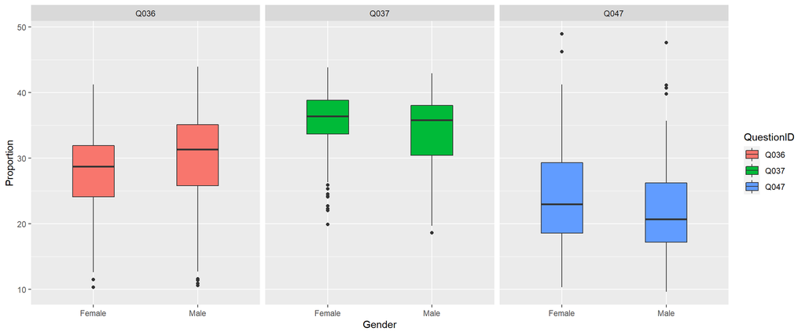

```r
ggplot(data=newd, aes(x=Gender,y=Proportion, fill = QuestionID)) +
  geom_boxplot(width = 0.4) +
  facet_wrap(~QuestionID)
```

From what is shown in the figure above, it can be seen that the difference in gender causes changes in the data. As in Q036, male have a greater influence on the percentage of obese adults over 18 years old. However, in Q037 and Q048, female have a higher propotion of data.

### 3.2 Education

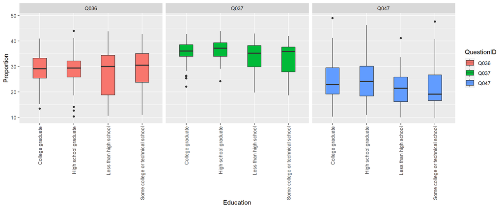

```r
ggplot(data=newd, aes(x=Education,y=Proportion, fill = QuestionID)) +
  geom_boxplot(width = 0.4) +
  facet_wrap(~QuestionID) +
  theme(axis.text.x = element_text(angle = 90, vjust = 0.5, hjust=1))
```

### 3.3 Income

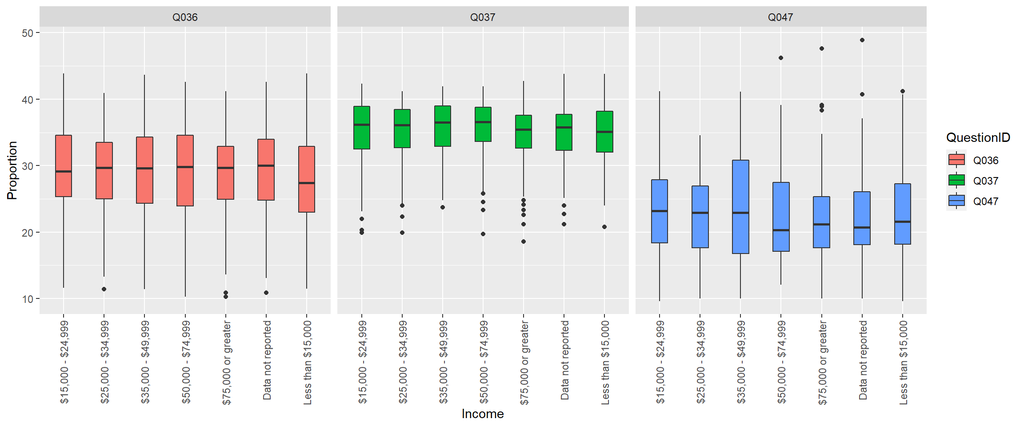

```r
ggplot(data=newd, aes(x=Income,y=Proportion, fill = QuestionID)) +
  geom_boxplot(width = 0.4) +
  facet_wrap(~QuestionID) +
  theme(axis.text.x = element_text(angle = 90, vjust = 0.5, hjust=1))
```

### 3.4 Race

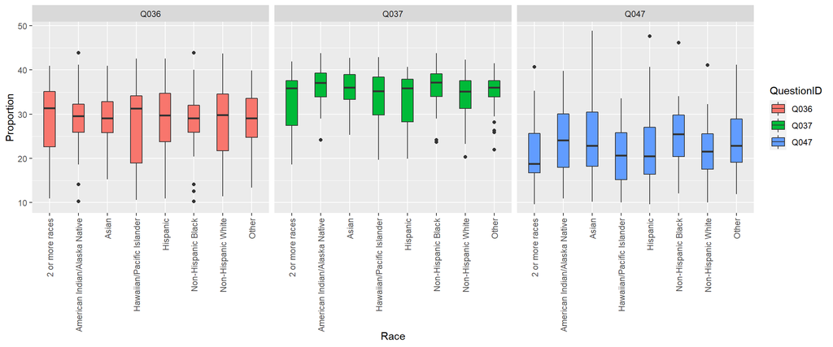

```r
ggplot(data=newd, aes(x=Race,y=Proportion, fill = QuestionID)) +
  geom_boxplot(width = 0.4) +
  facet_wrap(~QuestionID) +
  theme(axis.text.x = element_text(angle = 90, vjust = 0.5, hjust=1))
```

## 4.Method

### 4.1.1 Model

```r
m <- lm(Proportion ~., data= newd)
ols_step_all_possible(m)
```

```
##    Index N                              Predictors    R-Square Adj. R-Square
## 1      1 1                              QuestionID 0.351332304  0.3503289510
## 3      2 1                               Education 0.016858776  0.0145759404
## 5      3 1                                    Race 0.015984281  0.0106363692
## 2      4 1                                  Gender 0.003201551  0.0024312280
## 4      5 1                                  Income 0.001456936 -0.0031910531
## 7      6 2                    QuestionID Education 0.368128654  0.3656795404
## 9      7 2                         QuestionID Race 0.367926856  0.3635033271
## 6      8 2                       QuestionID Gender 0.352893117  0.3513905465
## 8      9 2                       QuestionID Income 0.352410534  0.3483851141
## 14    10 2                          Education Race 0.018704287  0.0110677448
## 13    11 2                        Education Income 0.018311822  0.0114415313
## 10    12 2                        Gender Education 0.017585762  0.0145418756
## 15    13 2                             Income Race 0.017384909  0.0074207936
## 12    14 2                             Gender Race 0.016245484  0.0101304603
```

[output cut: 49 more lines]

Since we have five predictor variables, we have 31 combinations of models. The above is the arrangement of the five predictors. Among them, index1-5 is a model controlled by a single predictor; 6-15 are two predictors; 16-25 are three predictors; 26-30 are four predictors; 31 is a model controlled by five predictors.

### 4.1.2 Model Plot

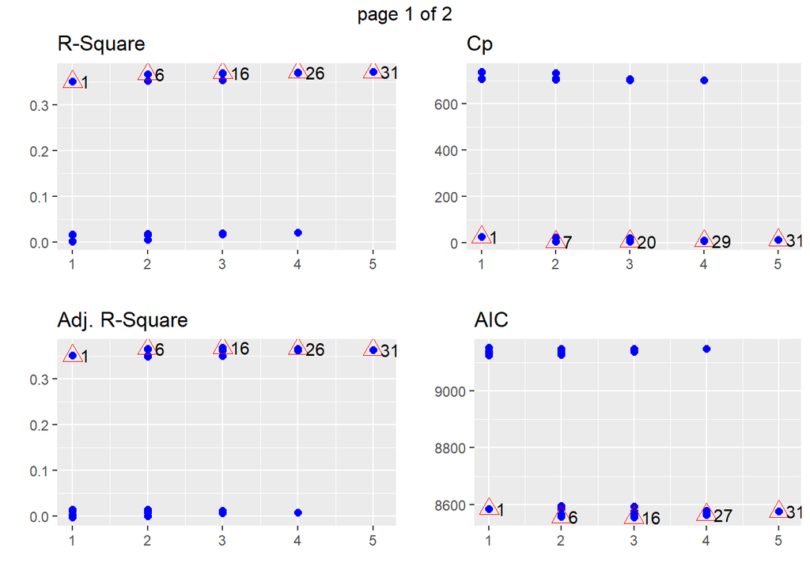

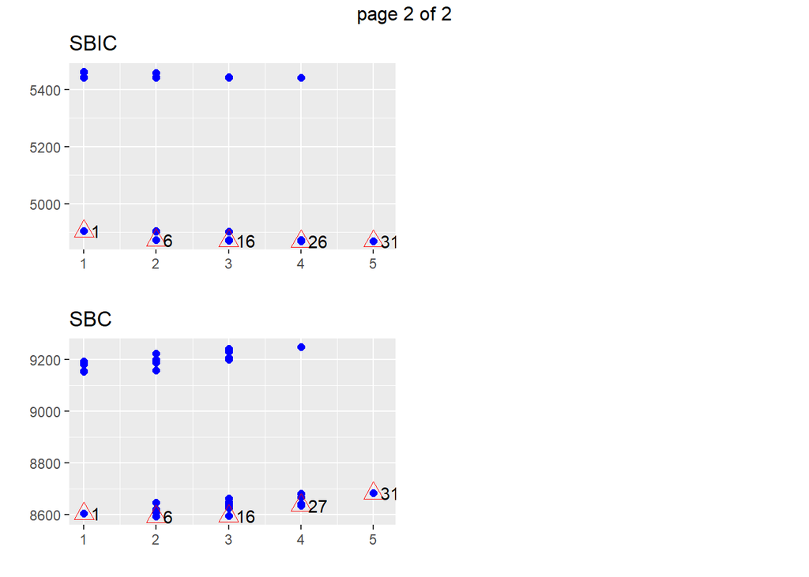

```r
plot(ols_step_all_possible(m))
```

In general, the larger R-Squared means the better model’s fitting effect. However, as the number of variables increases, R-Squared will inevitably increase, so it is impossible to truly quantify the degree of accuracy, but only roughly quantify. Therefore, we use the adjusted coefficient of determination, which is the adjusted fitting coefficient, to remove the increase in the R-squared effect of the increase in explanatory variables, so the largest value is the best in Adj.R-square,so 6, 16, 26, 31 are better. C(p) values as small as possible, so 7, 20, 29 are better. AIC and BIC are used to measure model fit and model size, so we give preference to models with smaller values of AIC and SBC with 6 and 16. In summary, 6 and 16 are relatively good, but they cannot be used as the final result. We have to refer to the result obtained by backward.

### 4.2 Best Subset Regression

```r
ols_step_best_subset(m)
```

```
##                Best Subsets Regression
## ------------------------------------------------------
## Model Index    Predictors
## ------------------------------------------------------
##      1         QuestionID
##      2         QuestionID Education
##      3         QuestionID Gender Education
##      4         QuestionID Gender Education Race
##      5         QuestionID Gender Education Income Race
## ------------------------------------------------------
##
##                                                        Subsets Regression Summary
## ----------------------------------------------------------------------------------------------------------------------------------------
##                        Adj.        Pred
## Model    R-Square    R-Square    R-Square     C(p)         AIC         SBIC          SBC          MSEP         FPE       HSP       APC
## ----------------------------------------------------------------------------------------------------------------------------------------
##   1        0.3513      0.3503      0.3483    27.5117    8584.8315    4904.8709    8605.4996    56876.1129    43.9876    0.0340    0.6507
##   2        0.3681      0.3657      0.3622    -4.6553    8556.8312    4872.9921    8593.0005    55446.2667    42.9813    0.0332    0.6348
##   3        0.3704      0.3675      0.3635    -7.2930    8554.1466    4870.3531    8595.4829    55288.9996    42.8925    0.0331    0.6335
##   4        0.3719      0.3655      0.3586    -8.2889    8565.1113    4869.3654    8642.6169    55202.4234    43.0589    0.0333    0.6330
##   5        0.3727      0.3634      0.3535    -8.0000    8575.3746    4869.6735    8683.8824    55171.2664    43.2366    0.0334    0.6331
## ----------------------------------------------------------------------------------------------------------------------------------------
## AIC: Akaike Information Criteria
##  SBIC: Sawa's Bayesian Information Criteria
##  SBC: Schwarz Bayesian Criteria
##  MSEP: Estimated error of prediction, assuming multivariate normality
##  FPE: Final Prediction Error
##  HSP: Hocking's Sp
##  APC: Amemiya Prediction Criteria
```

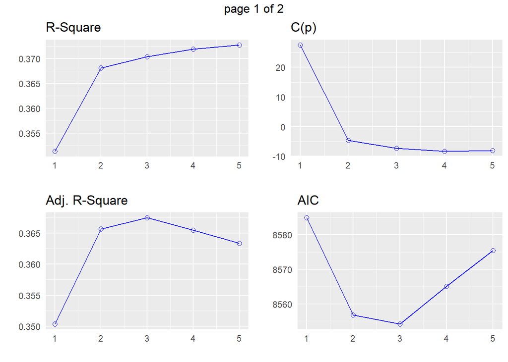

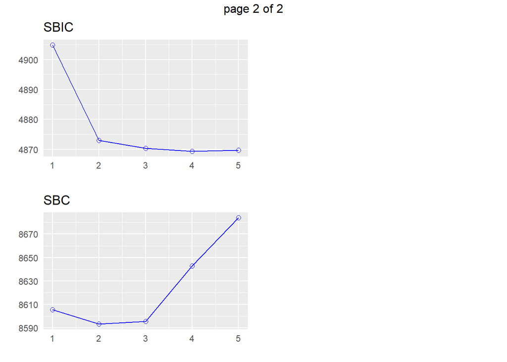

```r
plot(ols_step_best_subset(m))
```

Through further analysis, we found that more variables are not response the better model. This can be seen by the figure of Adj.R-squared. Therefore, Model 3 is more appropriate. The smaller value of C(p), the more suitable of the model, so 3, 4, and 5 are more suitable. Model 3 is the most smallest value in the AIC figure, so it is the best. In SBC, model 2 and model 3 are more suitable. The abscissa of the line chart represents the number of variables in the model, so it is more appropriate for the model to contain 3 variables.

### 4.3 Backward

```r
ols_step_backward_p(m)
```

```
##
##
##                            Elimination Summary
## --------------------------------------------------------------------------
##         Variable                  Adj.
## Step    Removed     R-Square    R-Square     C(p)         AIC        RMSE
## --------------------------------------------------------------------------
##    1    Income        0.3719      0.3655    -8.2889    8565.1113    6.5493
##    2    Race          0.3704      0.3675    -7.2930    8554.1466    6.5392
## --------------------------------------------------------------------------
```

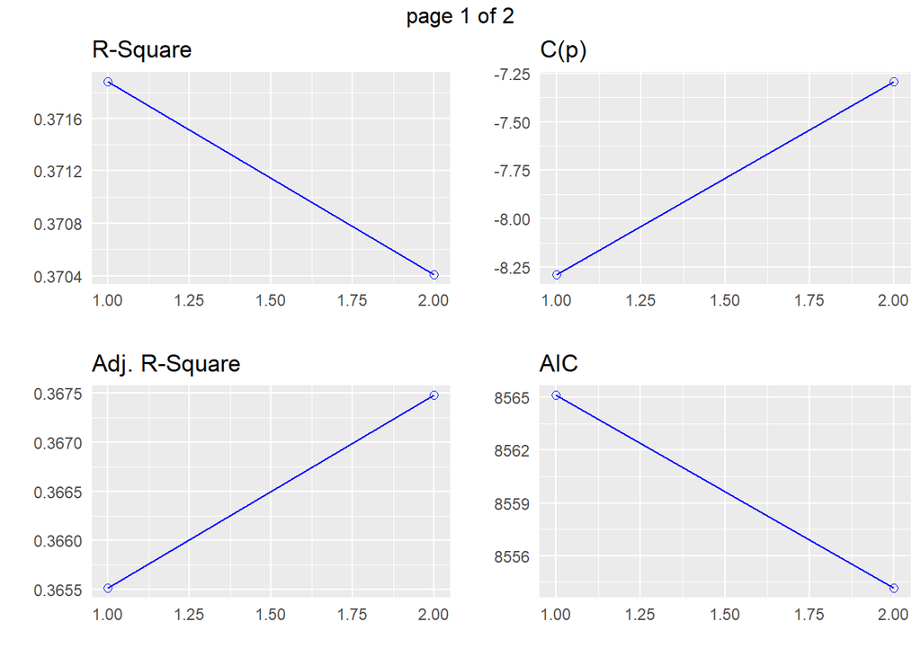

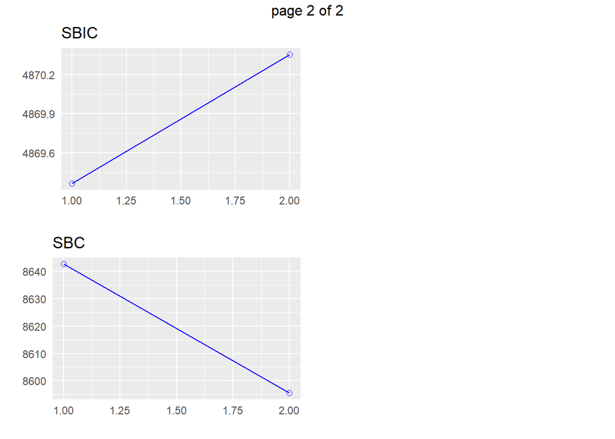

```r
plot(ols_step_backward_p(m))
```

The backward method is to obtain suitable variables by gradually deleting the predictor variables. This method based on the P-value and build a regression model from a set of predefined variables until there are no remaining variables to delete. We assume that all five predictors exist in the model.Through screening, we deleted Income and Race. The final model only contains QuestionID, Gender and Education, the specific analysis is shown in the figure below.

## 5.Result

### 5.1 Final Model

```r
m <- lm(Proportion ~ QuestionID + Gender + Education, data= newd)
summary(m)
```

```
##
## Call:
## lm(formula = Proportion ~ QuestionID + Gender + Education, data = newd)
##
## Residuals:
##      Min       1Q   Median       3Q      Max
## -19.3238  -4.3902   0.3675   4.6474  25.5588
##
## Coefficients:
##                                           Estimate Std. Error t value Pr(>|t|)
## (Intercept)                                29.2448     0.4555  64.200  < 2e-16
## QuestionIDQ037                              6.2372     0.4454  14.004  < 2e-16
## QuestionIDQ047                             -5.7301     0.4450 -12.877  < 2e-16
## GenderMale                                  0.9876     0.4571   2.161   0.0309
## EducationHigh school graduate               0.3790     0.5138   0.738   0.4608
## EducationLess than high school             -2.5755     0.5784  -4.453 9.21e-06
## EducationSome college or technical school  -2.4611     0.5888  -4.180 3.11e-05
##
## (Intercept)                               ***
## QuestionIDQ037                            ***
## QuestionIDQ047                            ***
## GenderMale                                *
## EducationHigh school graduate
## EducationLess than high school            ***
## EducationSome college or technical school ***
## ---
## Signif. codes:  0 '***' 0.001 '**' 0.01 '*' 0.05 '.' 0.1 ' ' 1
##
## Residual standard error: 6.539 on 1289 degrees of freedom
## Multiple R-squared:  0.3704, Adjusted R-squared:  0.3675
## F-statistic: 126.4 on 6 and 1289 DF,  p-value: < 2.2e-16
```

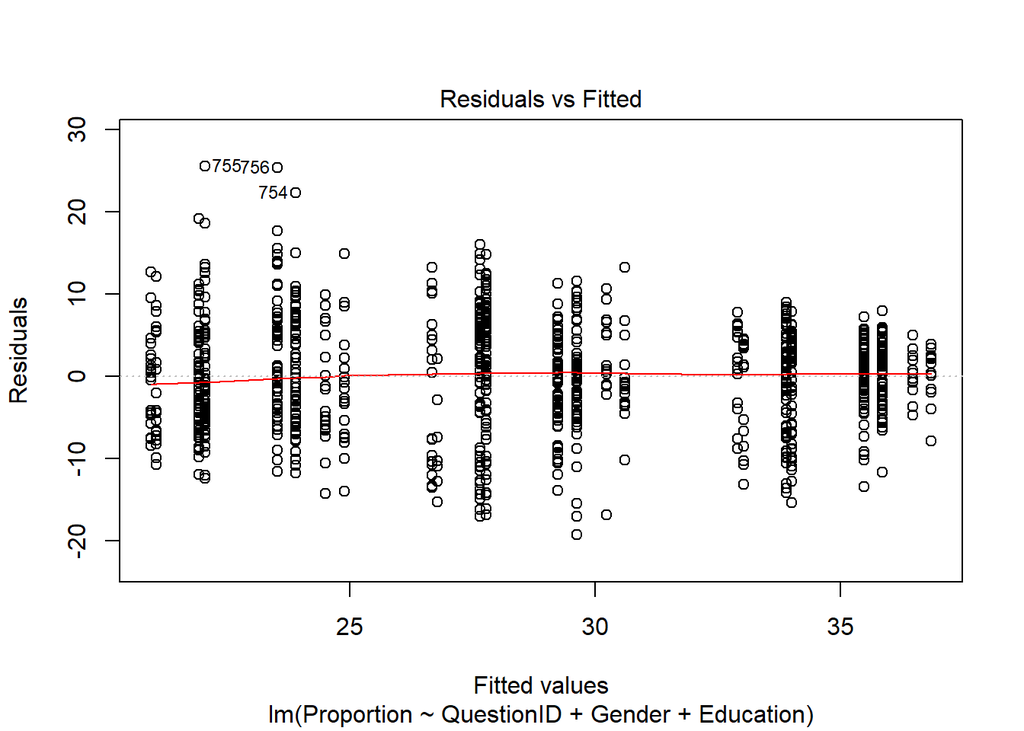

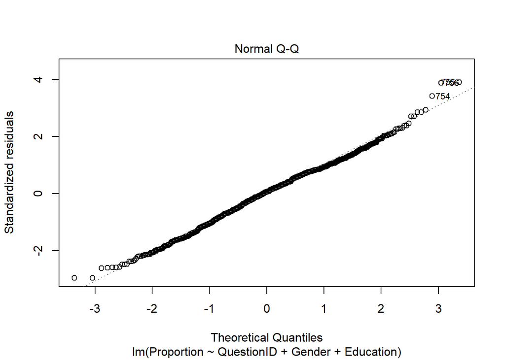

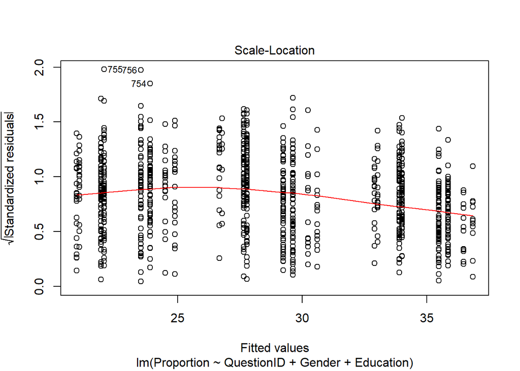

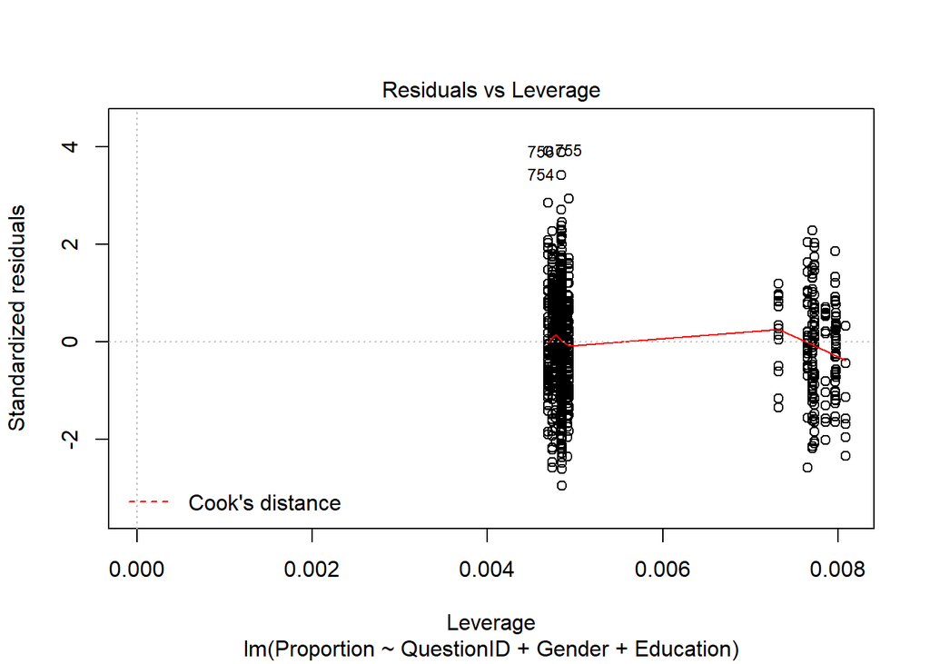

```r
plot(m)
```

Based on the above analysis, we can see that the proportion of adults aged 18 years and older who have obesity, percent of adults aged 18 years and older who have an overweight classification and percent of adults who engage in no leisure-time physical activity are significantly associated with gender and education status (p-value < 0.05).

## 7.Appendix

[Data source for the nutrition data](https://www.kaggle.com/spittman1248/cdc-data-nutrition-physical-activity-obesity)

[R Markdown file](https://github.com/Dal-stat-3340-final-project-group-9/Final-Project/blob/main/Final%20Project%20Group9.Rmd)